# Exploratory Data Analysis

Statistical Analysis and Temporal Patterns

## Overview

This page presents exploratory data analysis of our Reddit dataset, addressing 3 EDA business questions through statistical analysis, temporal patterns, and visualizations.

## Data Overview

### Dataset Summary

| data_type | date_range_end | date_range_start | size_gb | total_rows |
| --- | --- | --- | --- | --- |
| comments | 2024-07-31 | 2023-06-01 | 7.36 | 15803894 |
| submissions | 2024-07-31 | 2023-06-01 | 0.27 | 590019 |

**Key Statistics:**

- Total Comments: 15,803,894
- Total Submissions: 590,019
- Date Range: 2023-06-01 to 2024-07-31
- Number of Subreddits: 100

## Subreddit Popularity

### Business Question 1

**Question:** How popular is a particular subreddit in terms of unique users?

### Analysis Approach

- Group subreddits by city
- Extract week from created_utc timestamp
- Calculate unique commenters per week (removing repeat users)
- Average unique commenters over the year
- Generate visualizations comparing subreddit popularity

### Findings

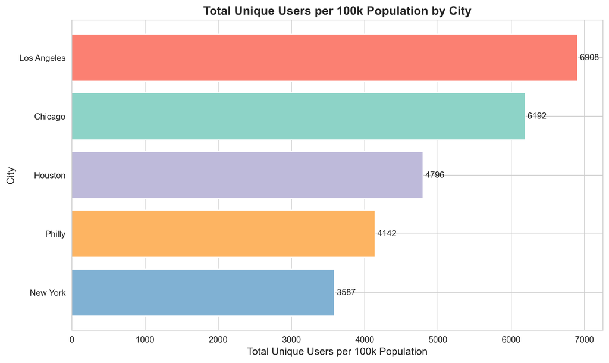

Fig 1. Unique Users

**Key Insight**

This bar graph compares the number of unique posters averaged by population size of each city. LA has the most unique users and new york has the fewest throughout the weeks of our data. Interestingly, the cities with the highest population don’t necessarily have the most unique users.

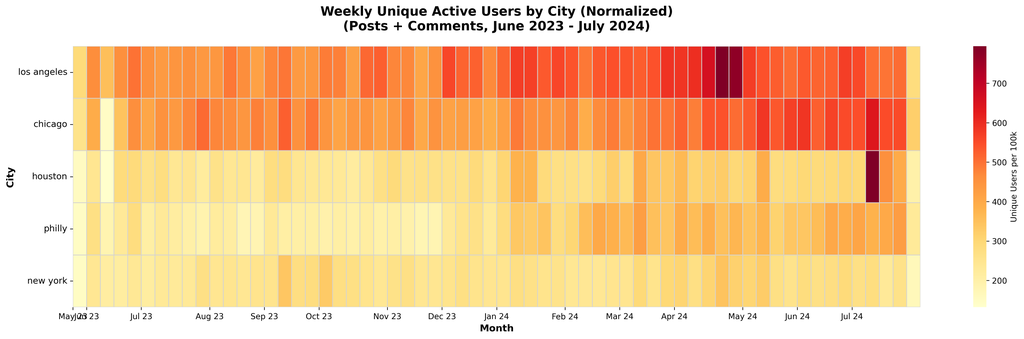

Fig 2. Weekly Users Heatmap

**Key Insight**

The heatmap shows the normalized number of unique users every week throughout the year in the range of our data. It shows that some subreddits are more event-driven (where people are responding to local news/events with spikes in activity), while other ones have continuously steady, low baseline activity regardless of what’s happening in their cities. An example of the event-driven one is Los Angeles, with several peaks throughout the year and generally high activity from unique users. New York, on the other hand, seems to have a general baseline of unique users without many spikes. The major peak in Houston in late July 2024 matches up with Hurricane Beryl and might be an indication of residents and people from other cities/states trying to communicate with people in Houston. The spikes in late April 2024 might correspond with protests related to Palestine, especially on college campuses whose subreddits were included in this analysis.

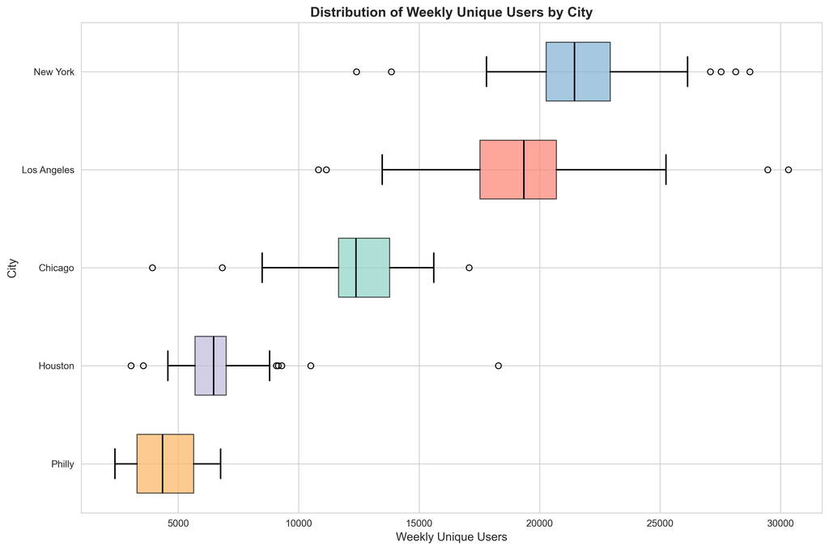

Fig 3. Weekly Activity Distribution

**Key Insight**

The largest subreddits seem to have the most variation in daily users, with New York and LA having the biggest ranges. Houston has the biggest outlier, which matches the finding of the heatmap.

## Posting Time

### Business Question 2

**Question:** What time of day do people post the most?

### Analysis Approach

- Take the submissions data and group by the subreddit for each individual city
- Use the created_utc variable to extract the hour of the day that the post was made and group by the hour
- Convert the UTC time stamps to the correct time zones based on the location of city that the subreddit corresponds to
- Count the number of unique submissions made during each hour
- Create time series plot that depicts the number of posts per hour of the day for each of the individual city subreddits

### Findings

In Figure 4, we see the aggregated number of postings per hour. Each of the lines indicate a distinct city and are normalized to the population size of the city and localized for the timezone.

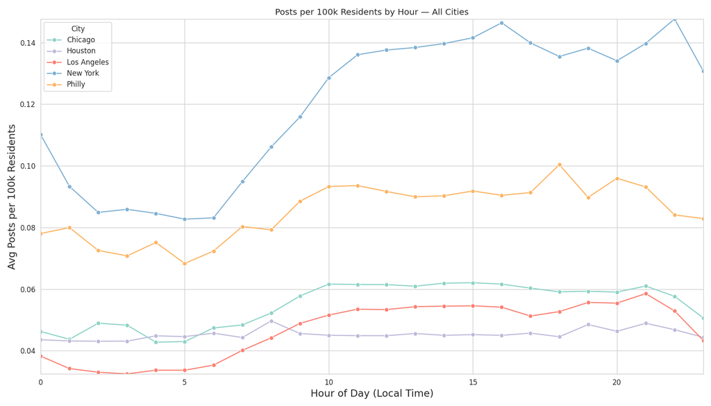

Fig 4. Time of Day

Immediately, we can compare the most popular city for Reddit, which is New York as it has the most posts per hour for every hour of the day. This is followed by Philadelphia, which has the second most number of posts per hour for all hours. Chicago, Los Angeles, and Houston all trade between 3rd, 4th, and 5th number of posts per hour.

**Key Insights:**

- Most Reddit users are posting between 10AM and 5PM (local time).
- Very few users are active during night hours.
- New York sees the highest number of posters at almost all hours of the day.
- Houston’s posting numbers are very consistent across all hours.

## Highest Scoring Posts

### Business Question 3

**Question:** Which kind of posts get the highest scores?

### Analysis Approach

- Utilize the dataset including all city subreddits
- Extract the score variable which indicates the number of upvotes minus the number of downvotes on the post
- Take the top 10% of posts in terms of score
- Match the post to a pre-specified topic using simple text processing (lowercasing, removing stopwords) and a Regex-based function
- Count the number of posts in the top 10% belonging to each topic category
- Create a bar chart that shows the number of high scoring posts across topics categories

### Findings

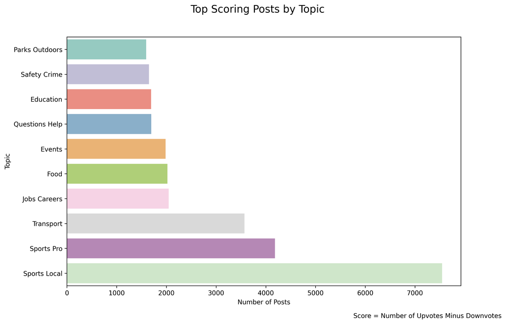

Fig 5. Highest Score Topics

**Key Insights:**

- Local sports dominate the top highest score posts across all city subreddits.
- Pro sports are the second most popular topic in terms of high scoring posts, showing that sports culture is a strong community engagement driver.
- Besides sports, the third top topic is transportation, indicating that transit issues are a key concern for many city residents.

## Temporal Analysis

### Posting Patterns Over Time

The biggest traffic for Reddit posting occurs on **Wednesday**, followed by Thursday and the least popular days are **Sunday** and **Saturday**. In terms of time of day, the top posting time is **11AM**, while **3AM** is the least popular posting time.

### Peak Activity Analysis

**Hourly Patterns:**

- Peak hours: 11:00 AM, 1:00 PM
- Lowest activity: 3:00 AM, 4:00 AM

**Table 1. Weekly Patterns:**

| Day | Total Posts |
| --- | --- |
| Sun | 73,072 |
| Mon | 82,420 |
| Tues | 85,700 |
| Weds | 88,610 |
| Thurs | 86,907 |
| Fri | 85,791 |
| Sat | 76,773 |

## Summary

**TipCode and Data**

All EDA code is available in `code/eda/` directory. Results are saved in `data/csv/` and visualizations in `data/plots/`.